# Домашнее задание № 2

## Основы исследовательского анализа данных.

## Требования к оформлению

- Оформить решение в R Markdown.
- Сохранить файл в свой репозиторий.
- Выгрузить R Markdown в HTML, назвать своим именем и отправить по почте (если хочется сдать раньше или нужна помощь).

## Исходные данные

По адресу https://raw.githubusercontent.com/SergeyMirvoda/da2016/master/data/calif_penn_2011.csv можно получить набор данных, содержащий информацию о домовладениях в Калифорнии и Пенсильвании за 2011г. Информация сгруппированна по зонам переписи ([Census tracts](https://en.wikipedia.org/wiki/Census_tract)).

> В построении диаграмм может помочь книга [The R Cookbook](http://shop.oreilly.com/product/9780596809164.do). Рецепты 10.1 и 10.2.

### Загрузка и очистка данных

- Загрузите данные в датафрейм, который назовите `data`.

```r
data<-read.csv("https://raw.githubusercontent.com/SergeyMirvoda/da2016/master/data/calif_penn_2011.csv")
```

- Сколько строк и столбцов в `data`?

```r
#Количество строк:
data.nrow<-nrow(data)
data.nrow
```

```
## [1] 11275
```

```r
#Количество столбцов:
data.ncol<-ncol(data)
data.ncol
```

```
## [1] 34
```

- Выполните следующую команду и объясните, что она делает. `colSums(apply(data,c(1,2), is.na))`

```r
colSums(apply(data,c(1,2), is.na))
```

```
##                           X                     GEO.id2
##                           0                           0
##                     STATEFP                    COUNTYFP
##                           0                           0
##                     TRACTCE                  POPULATION
##                           0                           0
##                    LATITUDE                   LONGITUDE
##                           0                           0
##           GEO.display.label          Median_house_value
##                           0                         599
##                 Total_units                Vacant_units
##                           0                           0
##                Median_rooms  Mean_household_size_owners
##                         157                         215
## Mean_household_size_renters         Built_2005_or_later
##                         152                          98
##          Built_2000_to_2004                 Built_1990s
##                          98                          98
##                 Built_1980s                 Built_1970s
##                          98                          98
##                 Built_1960s                 Built_1950s
##                          98                          98
##                 Built_1940s       Built_1939_or_earlier
##                          98                          98
##                  Bedrooms_0                  Bedrooms_1
##                          98                          98
##                  Bedrooms_2                  Bedrooms_3
##                          98                          98
##                  Bedrooms_4          Bedrooms_5_or_more
##                          98                          98
##                      Owners                     Renters
##                         100                         100
##     Median_household_income       Mean_household_income
##                         115                         126
```

```r
#colSums -ф-ия, кот-ая выводит количество значений TRUE для каждой колонки, данные значения получает ф-я apply
#apply- ф-я, кот-ая применяет действие ф-ии is.na к набору данных data, и возвращает TRUE, в случае если ф-ия вернет TRUE
#ф-ия с(1,2), в данном случае показывает, что применяется ф-ия и к столбцам и к строкам
#is.na -ф-я, к-ая определяет какие значения отсутствуют или помечены как NA

#Проверить количество NA в колонке Renters можно с помощью следующей команды:
length(data$Renters[is.na(data$Renters)])
```

```
## [1] 100
```

```r
#Значения совпадают
```

- Функция `na.omit()` принимает датафрейм и возвращает новый датафрейм, игнорируя строки, содержащие значение *NA*. Используйте эту функцию для удаления строк с неполными данными.

```r
data<-na.omit(data)
```

- Сколько строк было удалено?

```r
data.nrow-nrow(data)
```

```
## [1] 670
```

- Соответствует ли результат выполнения, значениям из пункта 3?

```r
colSums(apply(data,c(1,2), is.na))
```

```
##                           X                     GEO.id2
##                           0                           0
##                     STATEFP                    COUNTYFP
##                           0                           0
##                     TRACTCE                  POPULATION
##                           0                           0
##                    LATITUDE                   LONGITUDE
##                           0                           0
##           GEO.display.label          Median_house_value
##                           0                           0
##                 Total_units                Vacant_units
##                           0                           0
##                Median_rooms  Mean_household_size_owners
##                           0                           0
## Mean_household_size_renters         Built_2005_or_later
##                           0                           0
##          Built_2000_to_2004                 Built_1990s
##                           0                           0
##                 Built_1980s                 Built_1970s
##                           0                           0
##                 Built_1960s                 Built_1950s
##                           0                           0
##                 Built_1940s       Built_1939_or_earlier
##                           0                           0
##                  Bedrooms_0                  Bedrooms_1
##                           0                           0
##                  Bedrooms_2                  Bedrooms_3
##                           0                           0
##                  Bedrooms_4          Bedrooms_5_or_more
##                           0                           0
##                      Owners                     Renters
##                           0                           0
##     Median_household_income       Mean_household_income
##                           0                           0
```

При проверке количества NA в данных с помощью команды, приведенной выше, видно, что все строки, содержащие значение NA в какой-либо из колонок были очищены.

### Новые дома

- Переменная(колонка) *Built_2005_or_later* содержит данные о проценте домов, построенных с 2005 года. Постройте диаграмму рассеяния (scatterplot) медианы стоимости домов (переменная *Median_house_value*) относительно процента новых домов.

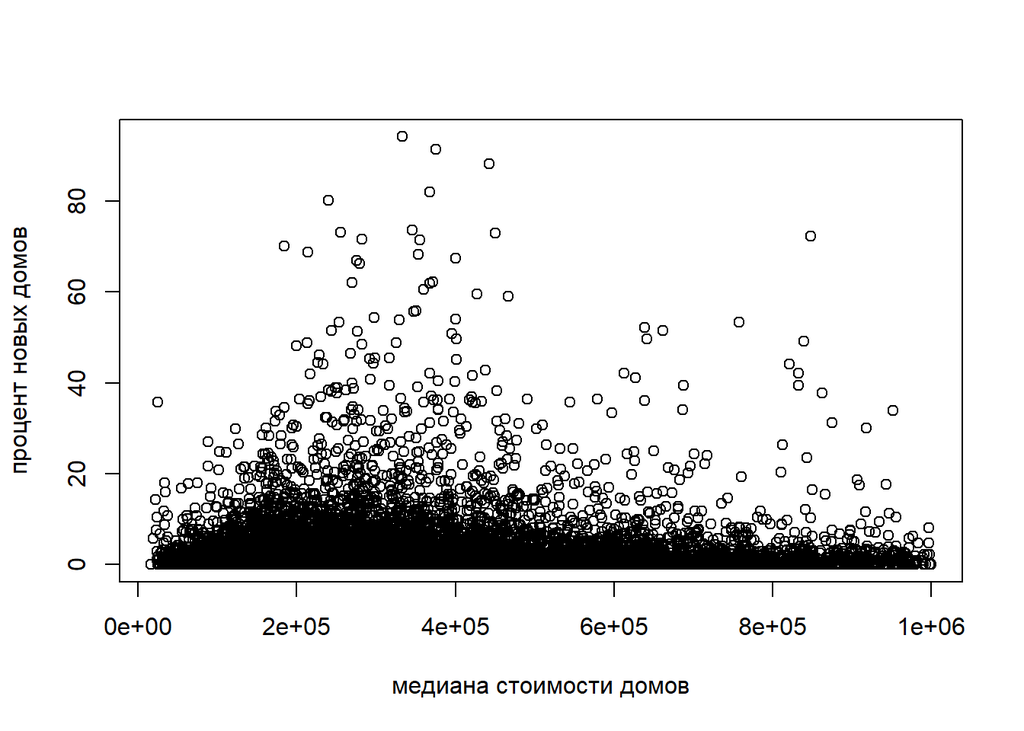

```r
plot(data$Median_house_value, data$Built_2005_or_later, xlab="медиана стоимости домов", ylab = "процент новых домов")
```

- Постройте ещё два графика для каждого из штатов отдельно. Номер штата содержится в переменной (*STATEFP*), где Калифорния 6-й штат, а Пенсильвания 42.

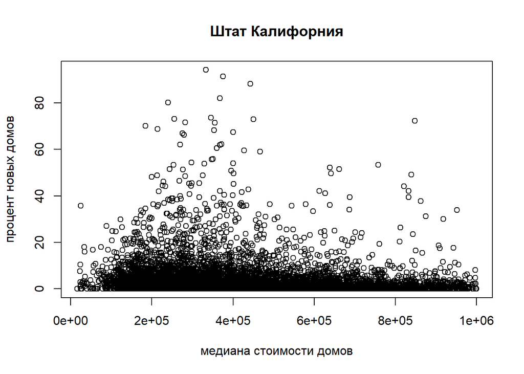

```r
plot(data$Median_house_value[data$STATEFP==6],data$Built_2005_or_later[data$STATEFP==6],xlab="медиана стоимости домов",ylab = "процент новых домов",main = "Штат Калифорния")
```

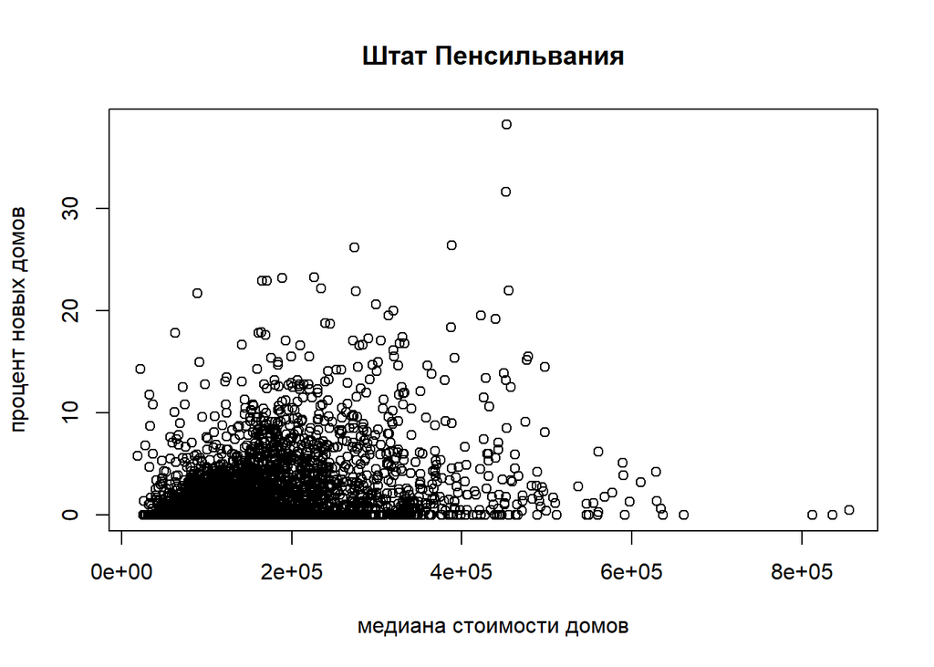

```r
plot(data$Median_house_value[data$STATEFP==42],data$Built_2005_or_later[data$STATEFP==42],xlab="медиана стоимости домов",ylab = "процент новых домов",main = "Штат Пенсильвания")
```

### Незанятые дома

Уровень найма (vacancy rate) — доля домов, которые не были заняты. В данных содержатся колонки, содержащие общее количество домовладений и количество не занятых домовладений.

- В датафрейм *data* добавьте новую колонку *vacancy_rate*, которая должна содержать вышеописанный показатель.

```r
#колонка total_units->общее количество домовладений
#колонка vacant_units-> свободные домовладения
data$vacancy_rate<-data$Vacant_units/data$Total_units
```

```r
#Минимум:
vacancy_rate.min<-min(data$vacancy_rate)
vacancy_rate.min
```

```
## [1] 0
```

```r
#Максимум:
vacancy_rate.max<-max(data$vacancy_rate)
vacancy_rate.max
```

```
## [1] 0.965311
```

```r
#Медиана:
vacancy_rate.median<-median(data$vacancy_rate)
vacancy_rate.median
```

```
## [1] 0.06767283
```

- Постройте диаграмму уровня найма относительно медианы стоимости домов. Что можно заметить?

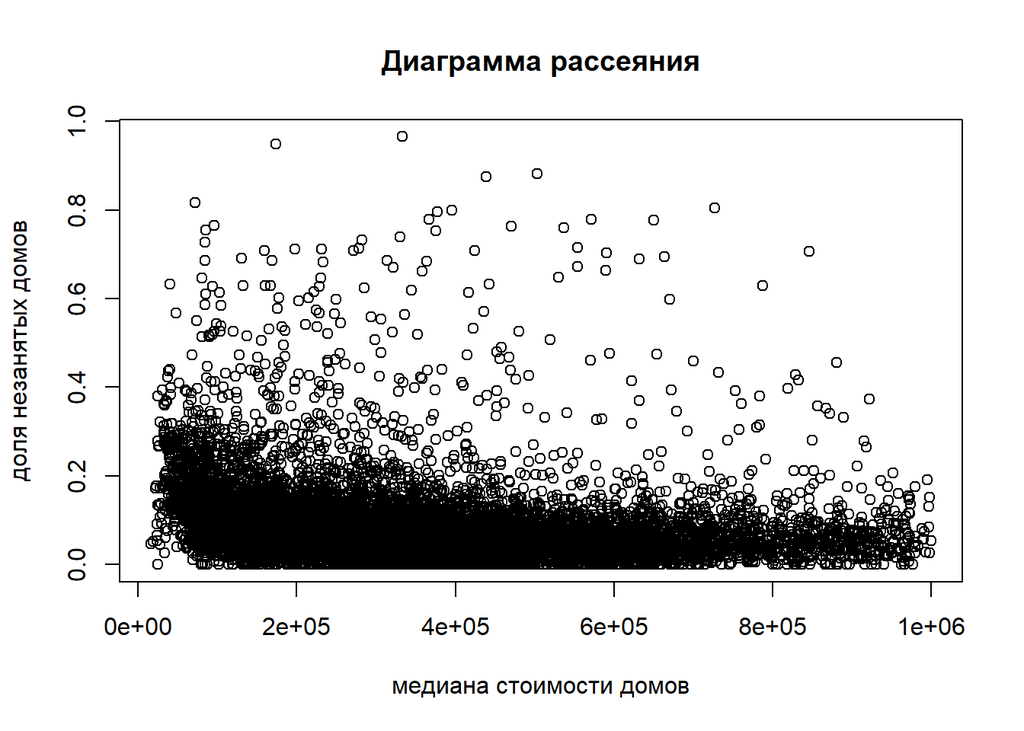

```r
plot(data$vacancy_rate~data$Median_house_value, xlab="медиана стоимости домов", ylab="доля незанятых домов",main="Диаграмма рассеяния")
```

Из данной диаграммы видно, что уровень найма тем больше, чем меньше медиана стоимости домовладений.

### Корреляция

Колонка *COUNTYFP* содержит числовой код округа внутри штата. Нас интересуют Butte County (округ 7 в Калифорнии), Santa Clara (округ 85 в Калифорнии) и York County (округ 133 в Пенсильвании).

- Объясните, что делает приведённый в конце задания код и как именно он это делает.

```r
acc <- c()
for (tract in 1:nrow(data)) {
  if (data$STATEFP[tract] == 6) {
    if (data$COUNTYFP[tract] == 1) {
      acc <- c(acc, tract)
    }
  }
}
accmv <- c()
for (tract in acc) {
  accmv <- c(accmv, data[tract,10])
}
median(accmv)
```

```
## [1] 474050
```

В приведенном выше коде вначале отбираются номера строк, со значением переменной *STATEFP* = 6 и *COUNTYFP* = 1, что соответствует округу №1 штату Калифорния. Данные номера записываются в переменную *acc*. Затем в следующем цикле в переменную *accmv* записываются значения 10 столбца и номера строки из переменной, полученной на предыдущем шаге, из датафрейма *data*. Т.е. записываются соответствующие медианы стоимости домов. В конце алгоритма берется медиана получившегося вектора значений.

- Напишите другим способом в одну строку, то же самое, что делает нижеуказанный код. Способов получить тот же ответ множество, достаточно одного.

```r
median(data$Median_house_value[data$STATEFP==6 & data$COUNTYFP==1])
```

```
## [1] 474050
```

- Найдите средний процент построенных домовладений в округах (Butte County, Santa Clara, York County)

```r
# процент построенных домов в Butte County (округ 7 в Калифорнии)
Butte_County.mean<-mean(data$Built_2005_or_later[data$STATEFP==6 & data$COUNTYFP==7])
Butte_County.mean
```

```
## [1] 4.703922
```

```r
# процент построенных домов в Santa Clara (округ 85 в Калифорнии)
Santa_Clara.mean<-mean(data$Built_2005_or_later[data$STATEFP==6 & data$COUNTYFP==85])
Santa_Clara.mean
```

```
## [1] 3.200319
```

```r
# процент построенных домов в York County (округ 133 в Пенсильвании)
York_County.mean<-mean(data$Built_2005_or_later[data$STATEFP==42 & data$COUNTYFP==133])
York_County.mean
```

```
## [1] 4.421111
```

- Функция `cor` рассчитывает коэффициент корреляции между двумя переменными. Рассчитайте корреляцию между медианы стоимости домовладений (*Median_house_value*) и процентом построенных домов (*Built_2005_or_later*):
1. для всего набора данных

```r
cor(data$Median_house_value, data$Built_2005_or_later)
```

```
## [1] -0.01893186
```

2. для Калифорнии

```r
cor(data$Median_house_value[data$STATEFP==6], data$Built_2005_or_later[data$STATEFP==6])
```

```
## [1] -0.1153604
```

3. для Пенсильвании

```r
cor(data$Median_house_value[data$STATEFP==42], data$Built_2005_or_later[data$STATEFP==42])
```

```
## [1] 0.2681654
```

4. для округа Butte County

```r
cor(data$Median_house_value[data$COUNTYFP==7], data$Built_2005_or_later[data$COUNTYFP==7])
```

```
## [1] 0.3254933
```

5. для округа Santa Clara

```r
cor(data$Median_house_value[data$COUNTYFP==85], data$Built_2005_or_later[data$COUNTYFP==85])
```

```
## [1] -0.08501218
```

6. для округа York County

```r
cor(data$Median_house_value[data$COUNTYFP==133], data$Built_2005_or_later[data$COUNTYFP==133])
```

```
## [1] 0.3860773
```

- Постройте три диаграммы медианы стоимости домовладений (*Median_house_value*) относительно медианы дохода (*Median_household_income*) для трёх округов. Допустимо указать все три на одном графике.

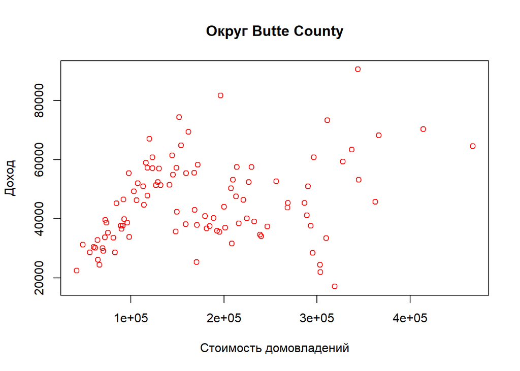

```r
#Butte County
x1<-data$Median_house_value[data$COUNTYFP==7]
y1<-data$Median_household_income[data$COUNTYFP==7]
plot(x1, y1,type="p",col="red", xlab ="Стоимость домовладений", ylab = "Доход",main = "Округ Butte County")
```

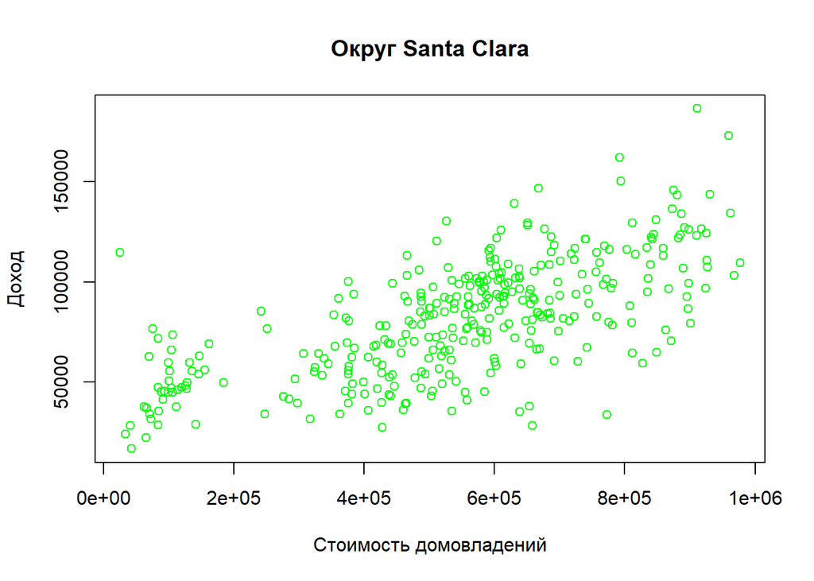

```r
#Santa Clara
x2<-data$Median_house_value[data$COUNTYFP==85]
y2<-data$Median_household_income[data$COUNTYFP==85]
plot(x2, y2,type="p",col="green", xlab ="Стоимость домовладений", ylab = "Доход",main = "Округ Santa Clara")
```

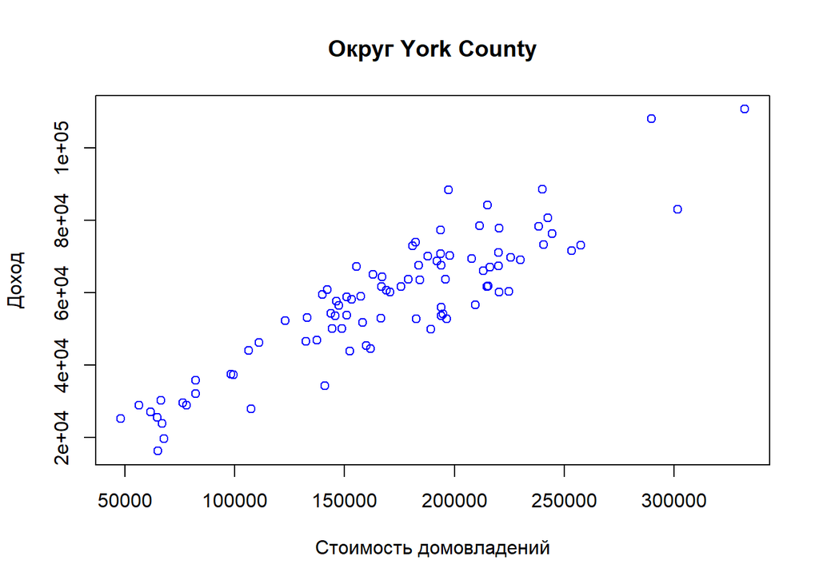

```r
#округ York County
x3<-data$Median_house_value[data$COUNTYFP==133]
y3<-data$Median_household_income[data$COUNTYFP==133]
plot(x3,y3,type="p",col="blue", xlab ="Стоимость домовладений", ylab = "Доход",main = "Округ York County")
```

#### Код

```
acc <- c()
for (tract in 1:nrow(ca_pa)) {
  if (ca_pa$STATEFP[tract] == 6) {
    if (ca_pa$COUNTYFP[tract] == 1) {
      acc <- c(acc, tract)
    }
  }
}
accmv <- c()
for (tract in acc) {
  accmv <- c(accmv, ca_pa[tract,10])
}
median(accmv)
```